# Housing Prices

# Preamble

## Load Packages

First load the packages, the advantage to the `pacman` package is that it will automatically install missing packages:

```r
if(require('pacman')){
  library('pacman')
}else{
  install.packages('pacman')
  library('pacman')
}
```

```r
pacman::p_load(xts, ggplot2, rmarkdown, reshape2, ggmap,
               RColorBrewer, parallel, dplyr, plotly)
```

## Import Datasets

Now we need to import the datastets:

```r
house.df <- read.csv(file = "house2018.csv", header = TRUE, sep = ",")
head(house.df)
```

```
##   home   nbhd offers sqm brick bedrooms bathrooms   price
## 1    1 nbhd02      2 166    No        2         2 1143000
## 2    2 nbhd02      3 188    No        4         2 1142000
## 3    3 nbhd02      1 161    No        3         2 1148000
## 4    4 nbhd02      3 183    No        3         2  947000
## 5    5 nbhd02      3 197    No        3         3 1198000
## 6    6 nbhd01      2 165    No        3         2 1146000
```

# Compare size and Price

If, on a fundamental level, the value of a property is dependent on its size, this can be visualised with a plot:

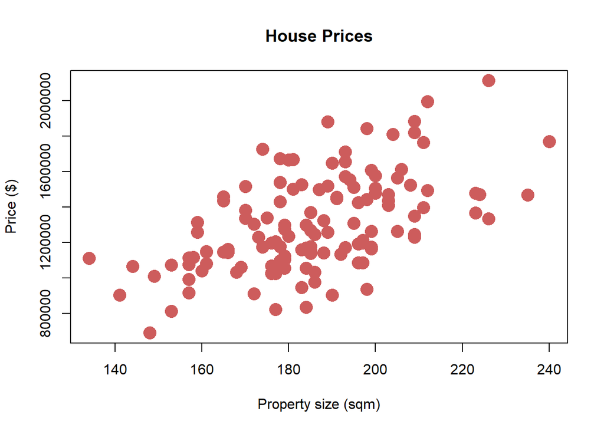

```r
plot.house <- function() {

  plot(x = house.df$sqm, y = house.df$price,
                   type = "p", main = "House Prices",
                   xlab = "Property size (sqm)", ylab = "Price ($)",
                   frame.plot = TRUE, axes = TRUE,
                   col = "Indianred", pch = 16, cex = 2)
  }

plot.house()
```

## Create a linear model

A linear regression can be created for this relationship:

```r
nbhd      <- house.df$nbhd
offers    <- house.df$offers
sqm       <- house.df$sqm
brick     <- house.df$brick
bedrooms  <- house.df$bedrooms
bathrooms <- house.df$bathrooms
price     <- house.df$price

house.lm <- lm(price ~ sqm)
summary(house.lm)
```

```
##
## Call:
## lm(formula = price ~ sqm)
##
## Residuals:
##     Min      1Q  Median      3Q     Max
## -464097 -166191  -14235  152348  548171
##
## Coefficients:
##             Estimate Std. Error t value Pr(>|t|)
## (Intercept)  -101785     188693  -0.539    0.591
## sqm             7585       1012   7.493 1.04e-11 ***
## ---
## Signif. codes:  0 '***' 0.001 '**' 0.01 '*' 0.05 '.' 0.1 ' ' 1
##
## Residual standard error: 224400 on 126 degrees of freedom
## Multiple R-squared:  0.3082, Adjusted R-squared:  0.3028
## F-statistic: 56.15 on 1 and 126 DF,  p-value: 1.038e-11
```

Thus the linear model can be seen to be:
$$Price = 7585 \times Size - 101785$$

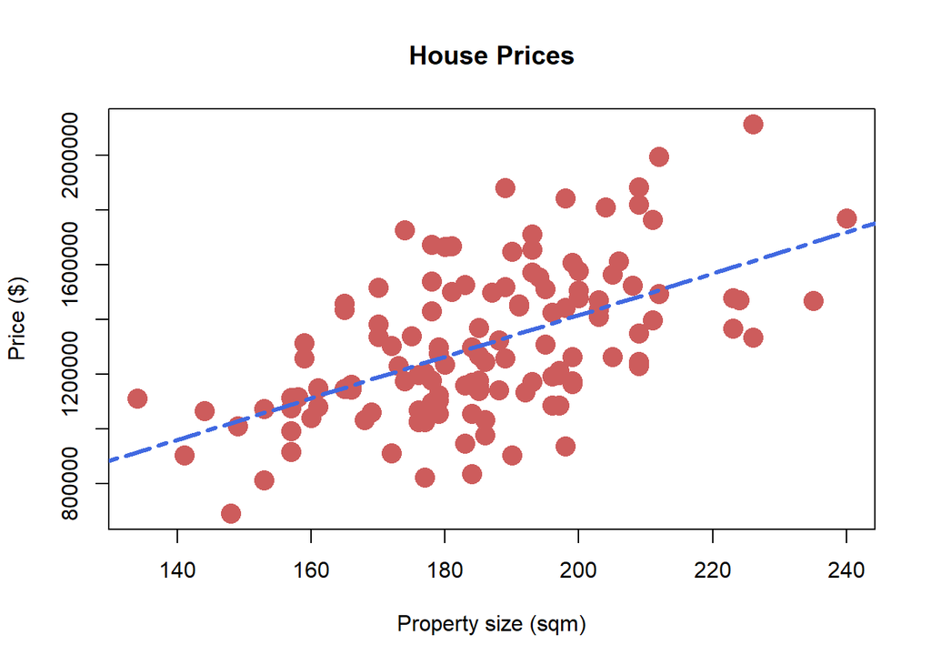

```r
plot.house.lm <- function(lm = TRUE) {
    plot.house()

  if(lm == TRUE) {
    abline(house.lm, col = "royalblue", lwd = 3, lty = 6)
  }
}

plot.house.lm(lm = TRUE)
```

Observe that the proportion of total variation explained by the linear model is only $r^2 = 30%$.

The large model residuals in this plot may be attributed as other variables being misinterpreted as noise, hence we can use `ggplot2` to visualise the other data and more appropriately consider the bivariate relationship.

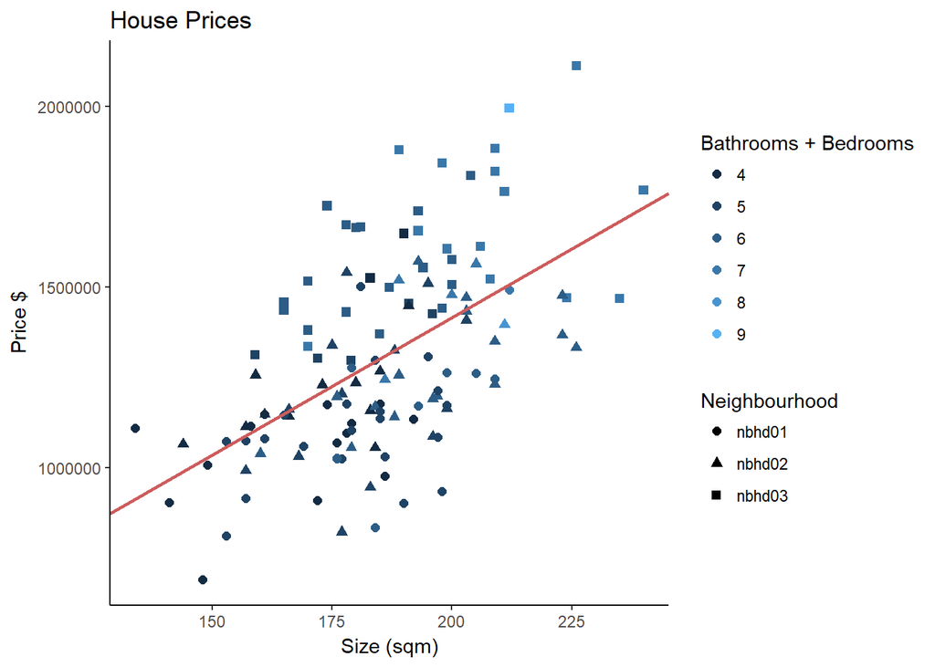

```r
ggplot(house.df, aes(x = sqm, y = price, shape = nbhd, label = brick, col = (bathrooms+ bedrooms))) +
  geom_point(size = 2) +
  guides(col = guide_legend(title = "Bathrooms + Bedrooms")) +
  guides(shape = guide_legend(title = "Neighbourhood")) +
  xlab("Size (sqm)") +
  ylab("Price $") +
  ggtitle("House Prices") +
  geom_abline(slope = house.lm$coefficients[2],
              intercept = house.lm$coefficients[1],
              lwd = 1, col = "indianred") +
  theme_classic()
```

# Multiple Linear Regression

Given that there are multiple factors influencing the price, a multiple linear regression could present a potential model for the plot:

```r
house.mlm <- lm(price ~ offers + sqm + bedrooms + bathrooms)
summary(house.mlm)
```

```
##
## Call:
## lm(formula = price ~ offers + sqm + bedrooms + bathrooms)
##
## Residuals:
##     Min      1Q  Median      3Q     Max
## -333286  -98074  -27613   93297  432674
##
## Coefficients:
##              Estimate Std. Error t value Pr(>|t|)
## (Intercept) -174460.5   126409.4  -1.380     0.17
## offers      -136168.2    13205.3 -10.312  < 2e-16 ***
## sqm            6697.6      886.3   7.557 8.17e-12 ***
## bedrooms      92571.1    21432.8   4.319 3.19e-05 ***
## bathrooms    126113.0    30986.8   4.070 8.35e-05 ***
## ---
## Signif. codes:  0 '***' 0.001 '**' 0.01 '*' 0.05 '.' 0.1 ' ' 1
##
## Residual standard error: 149500 on 123 degrees of freedom
## Multiple R-squared:    0.7,  Adjusted R-squared:  0.6903
## F-statistic: 71.76 on 4 and 123 DF,  p-value: < 2.2e-16
```

Thus a potential multiple linear regression could be:
$$Price = -174461 -136168 \times Offers + 6698 \times Size + 92571 \times bedrooms + 126113 \times bathrooms$$

# Answers

## 1. Price a 210sqm house

The prediction for the price of a 210 sqm house would be:

```r
#always use assignments when using the predict() function
price <- house.df$price
sqm   <- house.df$sqm

predict(lm(price ~ sqm), data.frame(sqm=210), interval = "prediction", level = 0.95)
```

```
##       fit     lwr     upr
## 1 1491120 1042669 1939571
```

```r
predict(house.mlm, data.frame(offers = mean(offers), sqm = 210, bedrooms = mean(bedrooms), bathrooms = mean(bathrooms)), interval = "prediction", level = 0.95)
```

```
##       fit     lwr     upr
## 1 1469255 1168991 1769520
```

## 2. Value of a 15sqm extension

The modelled price of a property changes in direct proportion to the size of the property at a rate equivilant to the slope, thus a 15 sqm extension would be valued at:

```r
paste("$", round(house.lm$coefficients[2]) * 15)
```

```
## [1] "$ 113775"
```